# Final Project_MSantos

# Rates

Generates homicide rates and other variables from transformations

```r
#Homicide Rate
HomPop$HomRate <- (HomPop$Deaths1/HomPop$Pop1) * 100000

#Age Distribution
HomPop$Per15_24 <- ((HomPop$Pop9 + HomPop$Pop10)/HomPop$Pop1)*100


save(HomPop, Homicide, Mortality, Population, file = "Data/Objects Jan22_2017.RData")

#load("Data/Objects Jan22_2017.RData")
```

# Aggregated Trends

Plots for all data points with valid data in the dataframe

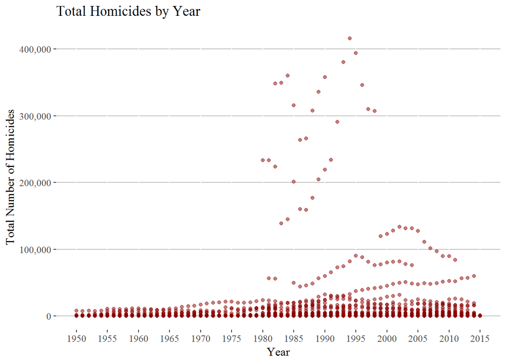

```r
usePackage('ggplot2')
usePackage('scales')

# 1. Investigate the prevalence of missing Homicide and Population Data by Country
  #Year; Deaths1; Pop1

  #Homicide
ggplot(HomPop[HomPop$Admin == "Country",], aes(x = Year)) +
    geom_point(aes(y = Deaths1), size = 1.5, color = "dark red", alpha = .5) +
    ggtitle("Total Homicides by Year") +
    ylab("Total Number of Homicides") +
    xlab("Year") +
    scale_x_continuous(breaks=seq(1950, 2015, 5), limits = c(1950, 2015)) +
    scale_y_continuous(labels = comma) +
    theme(
      text = element_text(family = "serif", size = 12),
      panel.grid.major.x = element_line(colour = "white"),
      panel.grid.major.y = element_line(colour = "gray"),
      panel.background = element_rect(fill = "white"))
```

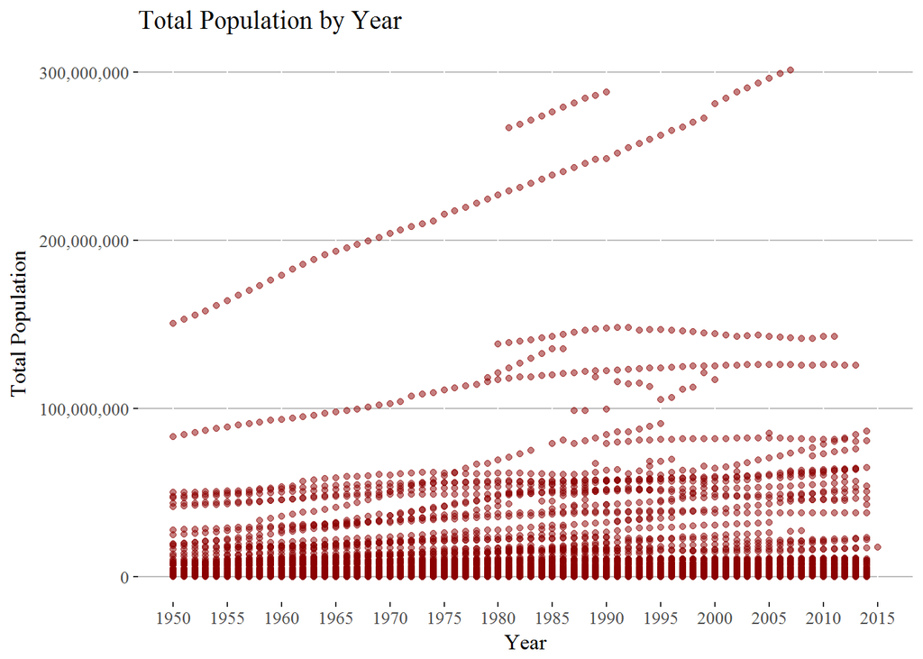

```r
  #Population
ggplot(HomPop[HomPop$Admin == "Country",], aes(x = Year)) +
    geom_point(aes(y = Pop1), size = 1.5, color = "dark red", alpha = .5) +
    ggtitle("Total Population by Year") +
    ylab("Total Population") +
    xlab("Year") +
    scale_x_continuous(breaks=seq(1950, 2015, 5), limits = c(1950, 2015)) +
    scale_y_continuous(labels = comma) +
    theme(
      text = element_text(family = "serif", size = 12),
      panel.grid.major.x = element_line(colour = "white"),
      panel.grid.major.y = element_line(colour = "gray"),
      panel.background = element_rect(fill = "white"))
```

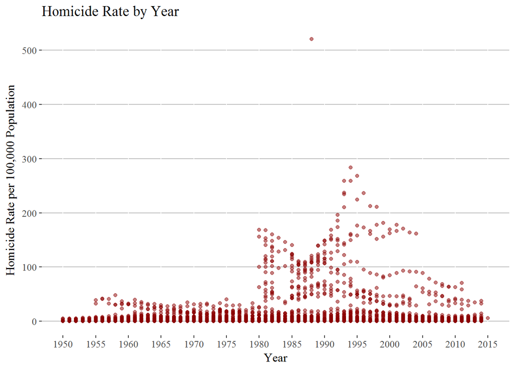

```r
# 2. Investigate shared trends in Homicide Rate and in the Proportion of the Population between 15 to 24 years
  #Year; HomRate; Per15_24

  #Homicide Rate
ggplot(HomPop[HomPop$Admin == "Country",], aes(x = Year)) +
    geom_point(aes(y = HomRate), size = 1.5, color = "dark red", alpha = .5) +
    ggtitle("Homicide Rate by Year") +
    ylab("Homicide Rate per 100,000 Population") +
    xlab("Year") +
    scale_x_continuous(breaks=seq(1950, 2015, 5), limits = c(1950, 2015)) +
    scale_y_continuous(labels = comma) +
    theme(
      text = element_text(family = "serif", size = 12),
      panel.grid.major.x = element_line(colour = "white"),
      panel.grid.major.y = element_line(colour = "gray"),
      panel.background = element_rect(fill = "white"))
```

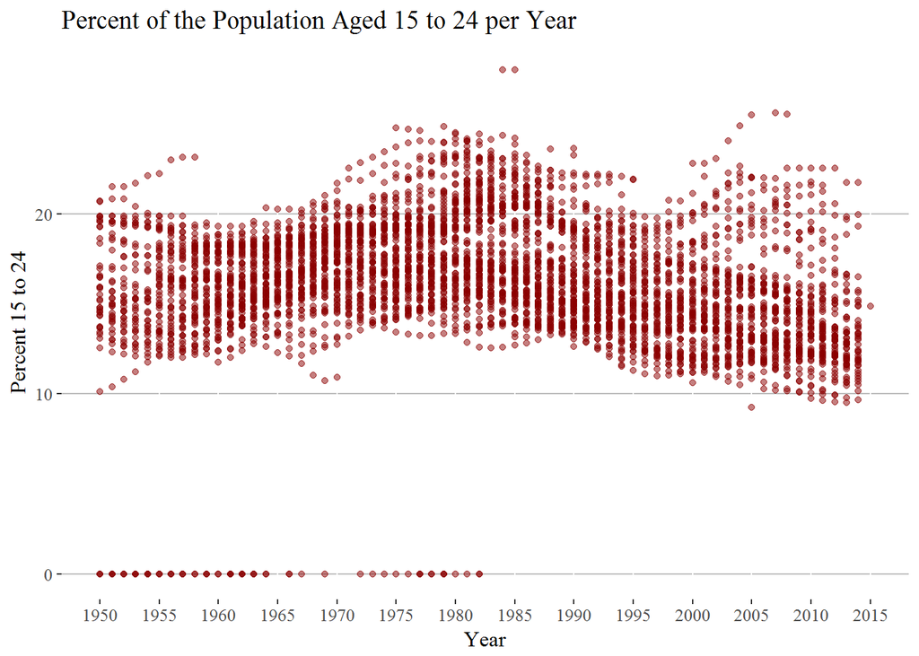

```r
  #Population 15 to 24
ggplot(HomPop[HomPop$Admin == "Country",], aes(x = Year)) +
    geom_point(aes(y = Per15_24), size = 1.5, color = "dark red", alpha = .5) +
    ggtitle("Percent of the Population Aged 15 to 24 per Year") +
    ylab("Percent 15 to 24") +
    xlab("Year") +
    scale_x_continuous(breaks=seq(1950, 2015, 5), limits = c(1950, 2015)) +
    scale_y_continuous(labels = comma) +
    theme(
      text = element_text(family = "serif", size = 12),
      panel.grid.major.x = element_line(colour = "white"),
      panel.grid.major.y = element_line(colour = "gray"),
      panel.background = element_rect(fill = "white"))
```

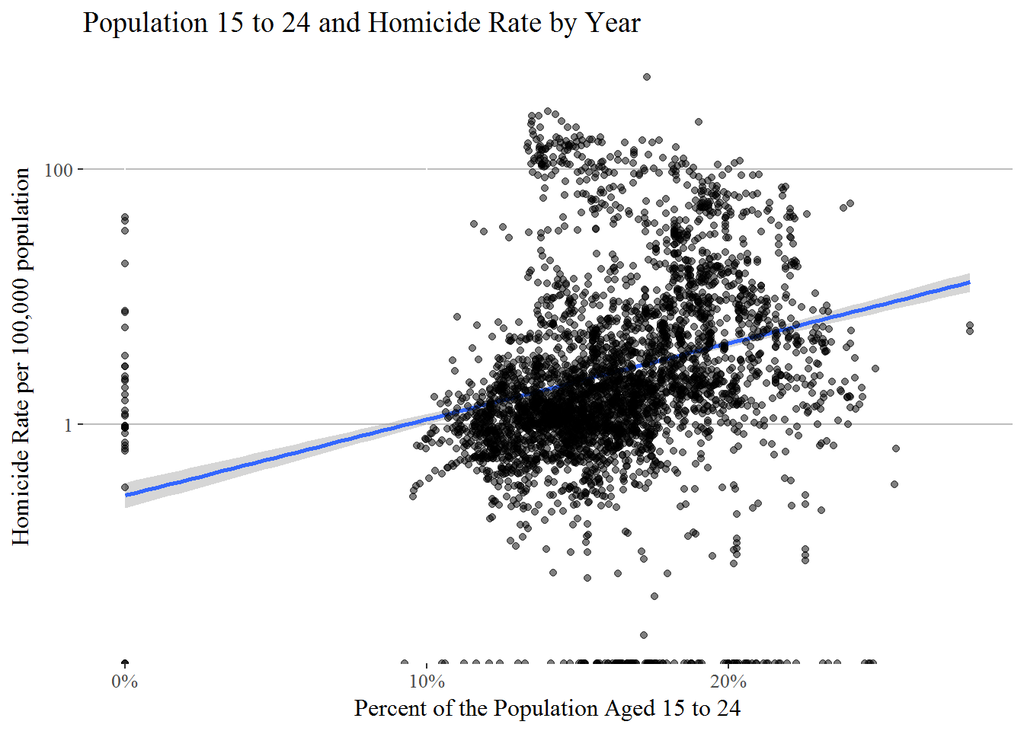

```r
# 3. Investigate the Association between Homicide Rates and the Proportion of the Population between 15 to 24 years
  #HomRate; Per15_24

ggplot(HomPop[HomPop$Admin == "Country", ], aes(Per15_24/100)) +
  geom_smooth(aes(y = HomRate), method = "lm") +
  geom_point(aes(y = HomRate), alpha = .5) +
  ggtitle("Population 15 to 24 and Homicide Rate by Year") +
  ylab("Homicide Rate per 100,000 population") +
  xlab("Percent of the Population Aged 15 to 24") +
  scale_x_continuous(labels = percent) +
  scale_y_log10(labels = comma) +
  theme(
    text = element_text(family = "serif", size = 12),
    panel.grid.major.x = element_line(colour = "white"),
    panel.grid.major.y = element_line(colour = "gray"),
    panel.background = element_rect(fill = "white"))
```

## Country-level Trends

Investigate trends in the data with individualized graphs by country

```r
usePackage('ggplot2')
usePackage('scales')
usePackage('gridExtra')

dir.create("Plots", showWarnings = FALSE)

# 1. Investigate the prevalence of missing Homicide and Population Data by Country
  #Deaths1 & Pop1

pdf("Plots/Year_Hom_Pop.pdf")

for (i in unique(HomPop$Country)) {

  Top <-
    ggplot(HomPop[HomPop$Country == i & HomPop$Admin == "Country", ], aes(x = Year)) +
    geom_line(aes(y = Deaths1), size = .5, color = "red") +
    geom_point(aes(y = Deaths1), size = 1.5, color = "dark red") +
    ggtitle(paste("Total Homicides - ",
                  unique(HomPop$Name[HomPop$Country == i]), " (",
                  unique(HomPop$Country[HomPop$Country == i]), ")")) +
    ylab("Total Number of Homicides") +
    xlab("Year") +
    scale_x_continuous(breaks=seq(1950, 2015, 5), limits = c(1950, 2015)) +
    scale_y_continuous(labels = comma) +
    theme(
      text = element_text(family = "serif", size = 12),
      panel.grid.major.x = element_line(colour = "white"),
      panel.grid.major.y = element_line(colour = "gray"),
      panel.background = element_rect(fill = "white"))

  Bottom <-
    ggplot(HomPop[HomPop$Country == i & HomPop$Admin == "Country", ], aes(x = Year)) +
    geom_line(aes(y = Pop1), size = .5, color = "blue") +
    geom_point(aes(y = Pop1), size = 1.5, color = "dark blue") +
    ggtitle(paste("Total Population - ",
                  unique(HomPop$Name[HomPop$Country == i]), " (",
                  unique(HomPop$Country[HomPop$Country == i]), ")")) +
    xlab("Year") +
    ylab("Total Population") +
    scale_x_continuous(breaks=seq(1950, 2015, 5), limits = c(1950, 2015)) +
    scale_y_continuous(labels = comma) +
    theme(
      text = element_text(family = "serif", size = 12),
      panel.grid.major.x = element_line(colour = "white"),
      panel.grid.major.y = element_line(colour = "gray"),
      panel.background = element_rect(fill = "white"))

  grid.arrange(Top, Bottom)

  print(paste(unique(HomPop$Name[HomPop$Country == i]), "(",
              unique(HomPop$Country[HomPop$Country == i]), ") Done."), sep = NULL)

}
```

```
## [1] "Cape Verde ( 1060 ) Done."
```

```
## [1] "Egypt ( 1125 ) Done."
```

```
## [1] "Mauritius ( 1300 ) Done."
```

```
## [1] "Mayotte ( 1303 ) Done."
```

```
## [1] "Morocco ( 1310 ) Done."
```

```
## [1] "Reunion ( 1360 ) Done."
```

```
## [1] "Rodrigues ( 1365 ) Done."
```

```
## [1] "Sao Tome and Principe ( 1385 ) Done."
```

```
## [1] "Seychelles ( 1400 ) Done."
```

```
## [1] "South Africa ( 1430 ) Done."
```

```
## [1] "Tunisia ( 1520 ) Done."
```

```
## [1] "Zimbabwe ( 1570 ) Done."
```

```
## [1] "Anguilla ( 2005 ) Done."
```

```
## [1] "Antigua and Barbuda ( 2010 ) Done."
```

```
## [1] "Argentina ( 2020 ) Done."
```

```
## [1] "Aruba ( 2025 ) Done."
```

```
## [1] "Bahamas ( 2030 ) Done."
```

```
## [1] "Barbados ( 2040 ) Done."
```

```
## [1] "Belize ( 2045 ) Done."
```

```
## [1] "Bermuda ( 2050 ) Done."
```

```
## [1] "Bolivia ( 2060 ) Done."
```

```
## [1] "Brazil ( 2070 ) Done."
```

```
## [1] "British Virgin Islands ( 2085 ) Done."
```

```
## [1] "Canada ( 2090 ) Done."
```

```
## [1] "Cayman Islands ( 2110 ) Done."
```

```
## [1] "Chile ( 2120 ) Done."
```

```
## [1] "Colombia ( 2130 ) Done."
```

```
## [1] "Costa Rica ( 2140 ) Done."
```

```
## [1] "Cuba ( 2150 ) Done."
```

```
## [1] "Dominica ( 2160 ) Done."
```

```
## [1] "Dominican Republic ( 2170 ) Done."
```

```
## [1] "Ecuador ( 2180 ) Done."
```

```
## [1] "El Salvador ( 2190 ) Done."
```

```
## [1] "Falkland Islands (Malvinas) ( 2200 ) Done."
```

```
## [1] "French Guiana ( 2210 ) Done."
```

```
## [1] "Grenada ( 2230 ) Done."
```

```
## [1] "Guadeloupe ( 2240 ) Done."
```

```
## [1] "Guatemala ( 2250 ) Done."
```

```
## [1] "Guyana ( 2260 ) Done."
```

```
## [1] "Haiti ( 2270 ) Done."
```

```
## [1] "Honduras ( 2280 ) Done."
```

```
## [1] "Jamaica ( 2290 ) Done."
```

```
## [1] "Martinique ( 2300 ) Done."
```

```
## [1] "Mexico ( 2310 ) Done."
```

```
## [1] "Montserrat ( 2320 ) Done."
```

```
## [1] "Netherlands Antilles ( 2330 ) Done."
```

```
## [1] "Nicaragua ( 2340 ) Done."
```

```
## [1] "Panama ( 2350 ) Done."
```

```
## [1] "Paraguay ( 2360 ) Done."
```

```
## [1] "Peru ( 2370 ) Done."
```

```
## [1] "Puerto Rico ( 2380 ) Done."
```

```
## [1] "Saint Kitts and Nevis ( 2385 ) Done."
```

```
## [1] "Saint Lucia ( 2400 ) Done."
```

```
## [1] "Saint Pierre and Miquelon ( 2410 ) Done."
```

```
## [1] "Saint Vincent and Grenadines ( 2420 ) Done."
```

```
## [1] "Suriname ( 2430 ) Done."
```

```
## [1] "Trinidad and Tobago ( 2440 ) Done."
```

```
## [1] "Turks and Caicos Islands ( 2445 ) Done."
```

```
## [1] "United States of America ( 2450 ) Done."
```

```
## [1] "Virgin Islands (USA) ( 2455 ) Done."
```

```
## [1] "Uruguay ( 2460 ) Done."
```

```
## [1] "Venezuela ( 2470 ) Done."
```

```
## [1] "Bahrain ( 3020 ) Done."
```

```
## [1] "Brunei Darussalam ( 3030 ) Done."
```

```
## [1] "China ( 3068 ) Done."
```

```
## [1] "China: Province of Taiwan only ( 3070 ) Done."
```

```
## [1] "Cyprus ( 3080 ) Done."
```

```
## [1] "Hong Kong SAR ( 3090 ) Done."
```

```
## [1] "Iran (Islamic Republic of) ( 3130 ) Done."
```

```
## [1] "Iraq ( 3140 ) Done."
```

```
## [1] "Israel ( 3150 ) Done."
```

```
## [1] "Japan ( 3160 ) Done."
```

```
## [1] "Jordan ( 3170 ) Done."
```

```
## [1] "Kuwait ( 3190 ) Done."
```

```
## [1] "Macau ( 3220 ) Done."
```

```
## [1] "Malaysia ( 3236 ) Done."
```

```
## [1] "Maldives ( 3255 ) Done."
```

```
## [1] "Mongolia ( 3260 ) Done."
```

```
## [1] "Myanmar ( 3270 ) Done."
```

```
## [1] "Occupied Palestinian Territory ( 3283 ) Done."
```

```
## [1] "Oman ( 3285 ) Done."
```

```
## [1] "Pakistan ( 3290 ) Done."
```

```
## [1] "Philippines ( 3300 ) Done."
```

```
## [1] "Qatar ( 3320 ) Done."
```

```
## [1] "Republic of Korea ( 3325 ) Done."
```

```
## [1] "Ryu Kyu Islands ( 3330 ) Done."
```

```
## [1] "Singapore ( 3350 ) Done."
```

```
## [1] "Sri Lanka ( 3365 ) Done."
```

```
## [1] "Syrian Arab Republic ( 3370 ) Done."
```

```
## [1] "Thailand ( 3380 ) Done."
```

```
## [1] "Turkey ( 3400 ) Done."
```

```
## [1] "Albania ( 4005 ) Done."
```

```
## [1] "Armenia ( 4007 ) Done."
```

```
## [1] "Austria ( 4010 ) Done."
```

```
## [1] "Azerbaijan ( 4012 ) Done."
```

```
## [1] "Belarus ( 4018 ) Done."
```

```
## [1] "Belgium ( 4020 ) Done."
```

```
## [1] "Bosnia and Herzegovina ( 4025 ) Done."
```

```
## [1] "Bulgaria ( 4030 ) Done."
```

```
## [1] "Croatia ( 4038 ) Done."
```

```
## [1] "Czechoslovakia, Former ( 4040 ) Done."
```

```
## [1] "Czech Republic ( 4045 ) Done."
```

```
## [1] "Denmark ( 4050 ) Done."
```

```
## [1] "Estonia ( 4055 ) Done."
```

```
## [1] "Finland ( 4070 ) Done."
```

```
## [1] "France ( 4080 ) Done."
```

```
## [1] "Georgia ( 4084 ) Done."
```

```
## [1] "Germany ( 4085 ) Done."
```

```
## [1] "Germany, Former Democratic Republic ( 4090 ) Done."
```

```
## [1] "Germany, Former Federal Republic ( 4100 ) Done."
```

```
## [1] "Germany, West Berlin ( 4120 ) Done."
```

```
## [1] "Greece ( 4140 ) Done."
```

```
## [1] "Hungary ( 4150 ) Done."
```

```
## [1] "Iceland ( 4160 ) Done."
```

```
## [1] "Ireland ( 4170 ) Done."
```

```
## [1] "Italy ( 4180 ) Done."
```

```
## [1] "Kazakhstan ( 4182 ) Done."
```

```
## [1] "Kyrgyzstan ( 4184 ) Done."
```

```
## [1] "Latvia ( 4186 ) Done."
```

```
## [1] "Lithuania ( 4188 ) Done."
```

```
## [1] "Luxembourg ( 4190 ) Done."
```

```
## [1] "TFYR Macedonia ( 4195 ) Done."
```

```
## [1] "Malta ( 4200 ) Done."
```

```
## [1] "Monaco ( 4205 ) Done."
```

```
## [1] "Montenegro ( 4207 ) Done."
```

```
## [1] "Netherlands ( 4210 ) Done."
```

```
## [1] "Norway ( 4220 ) Done."
```

```
## [1] "Poland ( 4230 ) Done."
```

```
## [1] "Portugal ( 4240 ) Done."
```

```
## [1] "Republic of Moldova ( 4260 ) Done."
```

```
## [1] "Romania ( 4270 ) Done."
```

```
## [1] "Russian Federation ( 4272 ) Done."
```

```
## [1] "Serbia ( 4273 ) Done."
```

```
## [1] "Slovakia ( 4274 ) Done."
```

```
## [1] "San Marino ( 4275 ) Done."
```

```
## [1] "Slovenia ( 4276 ) Done."
```

```
## [1] "Spain ( 4280 ) Done."
```

```
## [1] "Sweden ( 4290 ) Done."
```

```
## [1] "Switzerland ( 4300 ) Done."
```

```
## [1] "Tajikistan ( 4301 ) Done."
```

```
## [1] "Turkmenistan ( 4302 ) Done."
```

```
## [1] "Ukraine ( 4303 ) Done."
```

```
## [1] "USSR, Former ( 4304 ) Done."
```

```
## [1] "United Kingdom ( 4308 ) Done."
```

```
## [1] "United Kingdom, England and Wales ( 4310 ) Done."
```

```
## [1] "United Kingdom, Northern Ireland ( 4320 ) Done."
```

```
## [1] "United Kingdom, Scotland ( 4330 ) Done."
```

```
## [1] "Uzbekistan ( 4335 ) Done."
```

```
## [1] "Yugoslavia, Former ( 4340 ) Done."
```

```
## [1] "Serbia and Montenegro, Former ( 4350 ) Done."
```

```
## [1] "Australia ( 5020 ) Done."
```

```
## [1] "Fiji ( 5070 ) Done."
```

```
## [1] "Kiribati ( 5105 ) Done."
```

```
## [1] "New Zealand ( 5150 ) Done."
```

```
## [1] "Papua New Guinea ( 5195 ) Done."
```

```
## [1] "Tonga ( 5200 ) Done."
```

```r
dev.off()
```

```r
# 2. Investigate shared trends in Homicide Rate and in the Proportion of the Population between 15 to 24 years
  #Year; HomRate; Per15_24

pdf("Plots/Year_HomRate_Per1524.pdf")

for (i in unique(HomPop$Country)) {

  Top <-
    ggplot(HomPop[HomPop$Country == i & HomPop$Admin == "Country", ], aes(x = Year)) +
    geom_line(aes(y = HomRate), size = .5, color = "red") +
    geom_point(aes(y = HomRate), size = 1.5, color = "dark red") +
    ggtitle(paste("Homicide Rate - ",
                  unique(HomPop$Name[HomPop$Country == i]), " (",
                  unique(HomPop$Country[HomPop$Country == i]), ")")) +
    ylab("Homicide Rate per 100,000 population") +
    xlab("Year") +
    scale_x_continuous(breaks=seq(1950, 2015, 5), limits = c(1950, 2015)) +
    scale_y_continuous(labels = comma) +
    theme(
      text = element_text(family = "serif", size = 12),
      panel.grid.major.x = element_line(colour = "white"),
      panel.grid.major.y = element_line(colour = "gray"),
      panel.background = element_rect(fill = "white"))


  Bottom <-
    ggplot(HomPop[HomPop$Country == i & HomPop$Admin == "Country", ], aes(x = Year)) +
    geom_line(aes(y = Per15_24), size = .5, color = "blue") +
    geom_point(aes(y = Per15_24), size = 1.5, color = "dark blue") +
    ggtitle(paste("Percent Aged 15 to 24 - ",
                  unique(HomPop$Name[HomPop$Country == i]), " (",
                  unique(HomPop$Country[HomPop$Country == i]), ")")) +
    xlab("Year") +
    ylab("Percent of the Population Aged 15 to 24") +
    scale_x_continuous(breaks=seq(1950, 2015, 5), limits = c(1950, 2015)) +
    scale_y_continuous(labels = percent) +
    theme(
      text = element_text(family = "serif", size = 12),
      panel.grid.major.x = element_line(colour = "white"),
      panel.grid.major.y = element_line(colour = "gray"),
      panel.background = element_rect(fill = "white"))

  grid.arrange(Top, Bottom)

  print(paste(unique(HomPop$Name[HomPop$Country == i]), "(",
              unique(HomPop$Country[HomPop$Country == i]), ") Done."), sep = NULL)

}
```

```
## [1] "Cape Verde ( 1060 ) Done."
```

```
## [1] "Egypt ( 1125 ) Done."
```

```
## [1] "Mauritius ( 1300 ) Done."
```

```
## [1] "Mayotte ( 1303 ) Done."
```

```
## [1] "Morocco ( 1310 ) Done."
```

```
## [1] "Reunion ( 1360 ) Done."
```

```
## [1] "Rodrigues ( 1365 ) Done."
```

```
## [1] "Sao Tome and Principe ( 1385 ) Done."
```

```
## [1] "Seychelles ( 1400 ) Done."
```

```
## [1] "South Africa ( 1430 ) Done."
```

```
## [1] "Tunisia ( 1520 ) Done."
```

```
## [1] "Zimbabwe ( 1570 ) Done."
```

```
## [1] "Anguilla ( 2005 ) Done."
```

```
## [1] "Antigua and Barbuda ( 2010 ) Done."
```

```
## [1] "Argentina ( 2020 ) Done."
```

```
## [1] "Aruba ( 2025 ) Done."
```

```
## [1] "Bahamas ( 2030 ) Done."
```

```
## [1] "Barbados ( 2040 ) Done."
```

```
## [1] "Belize ( 2045 ) Done."
```

```
## [1] "Bermuda ( 2050 ) Done."
```

```
## [1] "Bolivia ( 2060 ) Done."
```

```
## [1] "Brazil ( 2070 ) Done."
```

```
## [1] "British Virgin Islands ( 2085 ) Done."
```

```
## [1] "Canada ( 2090 ) Done."
```

```
## [1] "Cayman Islands ( 2110 ) Done."
```

```
## [1] "Chile ( 2120 ) Done."
```

```
## [1] "Colombia ( 2130 ) Done."
```

```
## [1] "Costa Rica ( 2140 ) Done."
```

```
## [1] "Cuba ( 2150 ) Done."
```

```
## [1] "Dominica ( 2160 ) Done."
```

```
## [1] "Dominican Republic ( 2170 ) Done."
```

```
## [1] "Ecuador ( 2180 ) Done."
```

```
## [1] "El Salvador ( 2190 ) Done."
```

```
## [1] "Falkland Islands (Malvinas) ( 2200 ) Done."
```

```
## [1] "French Guiana ( 2210 ) Done."
```

```
## [1] "Grenada ( 2230 ) Done."
```

```
## [1] "Guadeloupe ( 2240 ) Done."
```

```
## [1] "Guatemala ( 2250 ) Done."
```

```
## [1] "Guyana ( 2260 ) Done."
```

```
## [1] "Haiti ( 2270 ) Done."
```

```
## [1] "Honduras ( 2280 ) Done."
```

```
## [1] "Jamaica ( 2290 ) Done."
```

```
## [1] "Martinique ( 2300 ) Done."
```

```
## [1] "Mexico ( 2310 ) Done."
```

```
## [1] "Montserrat ( 2320 ) Done."
```

```
## [1] "Netherlands Antilles ( 2330 ) Done."
```

```
## [1] "Nicaragua ( 2340 ) Done."
```

```
## [1] "Panama ( 2350 ) Done."
```

```
## [1] "Paraguay ( 2360 ) Done."
```

```
## [1] "Peru ( 2370 ) Done."
```

```
## [1] "Puerto Rico ( 2380 ) Done."
```

```
## [1] "Saint Kitts and Nevis ( 2385 ) Done."
```

```
## [1] "Saint Lucia ( 2400 ) Done."
```

```
## [1] "Saint Pierre and Miquelon ( 2410 ) Done."
```

```
## [1] "Saint Vincent and Grenadines ( 2420 ) Done."
```

```
## [1] "Suriname ( 2430 ) Done."
```

```
## [1] "Trinidad and Tobago ( 2440 ) Done."
```

```
## [1] "Turks and Caicos Islands ( 2445 ) Done."
```

```
## [1] "United States of America ( 2450 ) Done."
```

```
## [1] "Virgin Islands (USA) ( 2455 ) Done."
```

```
## [1] "Uruguay ( 2460 ) Done."
```

```
## [1] "Venezuela ( 2470 ) Done."
```

```
## [1] "Bahrain ( 3020 ) Done."
```

```
## [1] "Brunei Darussalam ( 3030 ) Done."
```

```
## [1] "China ( 3068 ) Done."
```

```
## [1] "China: Province of Taiwan only ( 3070 ) Done."
```

```
## [1] "Cyprus ( 3080 ) Done."
```

```
## [1] "Hong Kong SAR ( 3090 ) Done."
```

```
## [1] "Iran (Islamic Republic of) ( 3130 ) Done."
```

```
## [1] "Iraq ( 3140 ) Done."
```

```
## [1] "Israel ( 3150 ) Done."
```

```
## [1] "Japan ( 3160 ) Done."
```

```
## [1] "Jordan ( 3170 ) Done."
```

```
## [1] "Kuwait ( 3190 ) Done."
```

```
## [1] "Macau ( 3220 ) Done."
```

```
## [1] "Malaysia ( 3236 ) Done."
```

```
## [1] "Maldives ( 3255 ) Done."
```

```
## [1] "Mongolia ( 3260 ) Done."
```

```
## [1] "Myanmar ( 3270 ) Done."
```

```
## [1] "Occupied Palestinian Territory ( 3283 ) Done."
```

```
## [1] "Oman ( 3285 ) Done."
```

```
## [1] "Pakistan ( 3290 ) Done."
```

```
## [1] "Philippines ( 3300 ) Done."
```

```
## [1] "Qatar ( 3320 ) Done."
```

```
## [1] "Republic of Korea ( 3325 ) Done."
```

```
## [1] "Ryu Kyu Islands ( 3330 ) Done."
```

```
## [1] "Singapore ( 3350 ) Done."
```

```
## [1] "Sri Lanka ( 3365 ) Done."
```

```
## [1] "Syrian Arab Republic ( 3370 ) Done."
```

```
## [1] "Thailand ( 3380 ) Done."
```

```
## [1] "Turkey ( 3400 ) Done."
```

```
## [1] "Albania ( 4005 ) Done."
```

```
## [1] "Armenia ( 4007 ) Done."
```

```
## [1] "Austria ( 4010 ) Done."
```

```
## [1] "Azerbaijan ( 4012 ) Done."
```

```
## [1] "Belarus ( 4018 ) Done."
```

```
## [1] "Belgium ( 4020 ) Done."
```

```
## [1] "Bosnia and Herzegovina ( 4025 ) Done."
```

```
## [1] "Bulgaria ( 4030 ) Done."
```

```
## [1] "Croatia ( 4038 ) Done."
```

```
## [1] "Czechoslovakia, Former ( 4040 ) Done."
```

```
## [1] "Czech Republic ( 4045 ) Done."
```

```
## [1] "Denmark ( 4050 ) Done."
```

```
## [1] "Estonia ( 4055 ) Done."
```

```
## [1] "Finland ( 4070 ) Done."
```

```
## [1] "France ( 4080 ) Done."
```

```
## [1] "Georgia ( 4084 ) Done."
```

```
## [1] "Germany ( 4085 ) Done."
```

```
## [1] "Germany, Former Democratic Republic ( 4090 ) Done."
```

```
## [1] "Germany, Former Federal Republic ( 4100 ) Done."
```

```
## [1] "Germany, West Berlin ( 4120 ) Done."
```

```
## [1] "Greece ( 4140 ) Done."
```

```
## [1] "Hungary ( 4150 ) Done."
```

```
## [1] "Iceland ( 4160 ) Done."
```

```
## [1] "Ireland ( 4170 ) Done."
```

```
## [1] "Italy ( 4180 ) Done."
```

```
## [1] "Kazakhstan ( 4182 ) Done."
```

```
## [1] "Kyrgyzstan ( 4184 ) Done."
```

```
## [1] "Latvia ( 4186 ) Done."
```

```
## [1] "Lithuania ( 4188 ) Done."
```

```
## [1] "Luxembourg ( 4190 ) Done."
```

```
## [1] "TFYR Macedonia ( 4195 ) Done."
```

```
## [1] "Malta ( 4200 ) Done."
```

```
## [1] "Monaco ( 4205 ) Done."
```

```
## [1] "Montenegro ( 4207 ) Done."
```

```
## [1] "Netherlands ( 4210 ) Done."
```

```
## [1] "Norway ( 4220 ) Done."
```

```
## [1] "Poland ( 4230 ) Done."
```

```
## [1] "Portugal ( 4240 ) Done."
```

```
## [1] "Republic of Moldova ( 4260 ) Done."
```

```
## [1] "Romania ( 4270 ) Done."
```

```
## [1] "Russian Federation ( 4272 ) Done."
```

```
## [1] "Serbia ( 4273 ) Done."
```

```
## [1] "Slovakia ( 4274 ) Done."
```

```
## [1] "San Marino ( 4275 ) Done."
```

```
## [1] "Slovenia ( 4276 ) Done."
```

```
## [1] "Spain ( 4280 ) Done."
```

```
## [1] "Sweden ( 4290 ) Done."
```

```
## [1] "Switzerland ( 4300 ) Done."
```

```
## [1] "Tajikistan ( 4301 ) Done."
```

```
## [1] "Turkmenistan ( 4302 ) Done."
```

```
## [1] "Ukraine ( 4303 ) Done."
```

```
## [1] "USSR, Former ( 4304 ) Done."
```

```
## [1] "United Kingdom ( 4308 ) Done."
```

```
## [1] "United Kingdom, England and Wales ( 4310 ) Done."
```

```
## [1] "United Kingdom, Northern Ireland ( 4320 ) Done."
```

```
## [1] "United Kingdom, Scotland ( 4330 ) Done."
```

```
## [1] "Uzbekistan ( 4335 ) Done."
```

```
## [1] "Yugoslavia, Former ( 4340 ) Done."
```

```
## [1] "Serbia and Montenegro, Former ( 4350 ) Done."
```

```
## [1] "Australia ( 5020 ) Done."
```

```
## [1] "Fiji ( 5070 ) Done."
```

```
## [1] "Kiribati ( 5105 ) Done."
```

```
## [1] "New Zealand ( 5150 ) Done."
```

```
## [1] "Papua New Guinea ( 5195 ) Done."
```

```
## [1] "Tonga ( 5200 ) Done."
```

```r
dev.off()
```

```r
# 3. Investigate the Association between Homicide Rates and the Proportion of the Population between 15 to 24 years
  #HomRate; Per15_24

pdf("Plots/Scatter_HomRate_Per1524.pdf")

for (i in unique(HomPop$Country)) {
  dots <- ggplot(HomPop[HomPop$Country == i & HomPop$Admin == "Country", ],
                 aes(x = (Per15_24/100))) +
    geom_smooth(aes(y = HomRate), method = "lm") +
    geom_point(aes(y = HomRate), alpha = .5) +
    ggtitle(paste("Population 15 to 24 and Homicide Rate - ",
                  unique(HomPop$Name[HomPop$Country == i]), " (",
                  unique(HomPop$Country[HomPop$Country == i]), ")")) +
    ylab("Homicide Rate per 100,000 population") +
    xlab("Percent of the Population Aged 15 to 24") +
    scale_x_continuous(labels = percent) +
    scale_y_continuous(labels = comma) +
    theme(
      text = element_text(family = "serif", size = 12),
      panel.grid.major.x = element_line(colour = "white"),
      panel.grid.major.y = element_line(colour = "gray"),
      panel.background = element_rect(fill = "white"))

  grid.arrange(dots)

  print(paste(unique(HomPop$Name[HomPop$Country == i]), "(",
              unique(HomPop$Country[HomPop$Country == i]), ") Done."), sep = NULL)

}
```

```
## [1] "Cape Verde ( 1060 ) Done."
```

```
## [1] "Egypt ( 1125 ) Done."
```

```
## [1] "Mauritius ( 1300 ) Done."
```

```
## [1] "Mayotte ( 1303 ) Done."
```

```
## [1] "Morocco ( 1310 ) Done."
```

```
## [1] "Reunion ( 1360 ) Done."
```

```
## [1] "Rodrigues ( 1365 ) Done."
```

```
## [1] "Sao Tome and Principe ( 1385 ) Done."
```

```
## [1] "Seychelles ( 1400 ) Done."
```

```
## [1] "South Africa ( 1430 ) Done."
```

```
## [1] "Tunisia ( 1520 ) Done."
```

```
## [1] "Zimbabwe ( 1570 ) Done."
```

```
## [1] "Anguilla ( 2005 ) Done."
```

```
## [1] "Antigua and Barbuda ( 2010 ) Done."
```

```
## [1] "Argentina ( 2020 ) Done."
```

```
## [1] "Aruba ( 2025 ) Done."
```

```
## [1] "Bahamas ( 2030 ) Done."
```

```
## [1] "Barbados ( 2040 ) Done."
```

```
## [1] "Belize ( 2045 ) Done."
```

```
## [1] "Bermuda ( 2050 ) Done."
```

```
## [1] "Bolivia ( 2060 ) Done."
```

```
## [1] "Brazil ( 2070 ) Done."
```

```
## [1] "British Virgin Islands ( 2085 ) Done."
```

```
## [1] "Canada ( 2090 ) Done."
```

```
## [1] "Cayman Islands ( 2110 ) Done."
```

```
## [1] "Chile ( 2120 ) Done."
```

```
## [1] "Colombia ( 2130 ) Done."
```

```
## [1] "Costa Rica ( 2140 ) Done."
```

```
## [1] "Cuba ( 2150 ) Done."
```

```
## [1] "Dominica ( 2160 ) Done."
```

```
## [1] "Dominican Republic ( 2170 ) Done."
```

```
## [1] "Ecuador ( 2180 ) Done."
```

```
## [1] "El Salvador ( 2190 ) Done."
```

```
## [1] "Falkland Islands (Malvinas) ( 2200 ) Done."
```

```
## [1] "French Guiana ( 2210 ) Done."
```

```
## [1] "Grenada ( 2230 ) Done."
```

```
## [1] "Guadeloupe ( 2240 ) Done."
```

```
## [1] "Guatemala ( 2250 ) Done."
```

```
## [1] "Guyana ( 2260 ) Done."
```

```
## [1] "Haiti ( 2270 ) Done."
```

```
## [1] "Honduras ( 2280 ) Done."
```

```
## [1] "Jamaica ( 2290 ) Done."
```

```
## [1] "Martinique ( 2300 ) Done."
```

```
## [1] "Mexico ( 2310 ) Done."
```

```
## [1] "Montserrat ( 2320 ) Done."
```

```
## [1] "Netherlands Antilles ( 2330 ) Done."
```

```
## [1] "Nicaragua ( 2340 ) Done."
```

```
## [1] "Panama ( 2350 ) Done."
```

```
## [1] "Paraguay ( 2360 ) Done."
```

```
## [1] "Peru ( 2370 ) Done."
```

```
## [1] "Puerto Rico ( 2380 ) Done."
```

```
## [1] "Saint Kitts and Nevis ( 2385 ) Done."
```

```
## [1] "Saint Lucia ( 2400 ) Done."
```

```
## [1] "Saint Pierre and Miquelon ( 2410 ) Done."
```

```
## [1] "Saint Vincent and Grenadines ( 2420 ) Done."
```

```
## [1] "Suriname ( 2430 ) Done."
```

```
## [1] "Trinidad and Tobago ( 2440 ) Done."
```

```
## [1] "Turks and Caicos Islands ( 2445 ) Done."
```

```
## [1] "United States of America ( 2450 ) Done."
```

```
## [1] "Virgin Islands (USA) ( 2455 ) Done."
```

```
## [1] "Uruguay ( 2460 ) Done."
```

```
## [1] "Venezuela ( 2470 ) Done."
```

```
## [1] "Bahrain ( 3020 ) Done."
```

```
## [1] "Brunei Darussalam ( 3030 ) Done."
```

```
## [1] "China ( 3068 ) Done."
```

```
## [1] "China: Province of Taiwan only ( 3070 ) Done."
```

```
## [1] "Cyprus ( 3080 ) Done."
```

```
## [1] "Hong Kong SAR ( 3090 ) Done."
```

```
## [1] "Iran (Islamic Republic of) ( 3130 ) Done."
```

```
## [1] "Iraq ( 3140 ) Done."
```

```
## [1] "Israel ( 3150 ) Done."
```

```
## [1] "Japan ( 3160 ) Done."
```

```
## [1] "Jordan ( 3170 ) Done."
```

```
## [1] "Kuwait ( 3190 ) Done."
```

```
## [1] "Macau ( 3220 ) Done."
```

```
## [1] "Malaysia ( 3236 ) Done."
```

```
## [1] "Maldives ( 3255 ) Done."
```

```
## [1] "Mongolia ( 3260 ) Done."
```

```
## [1] "Myanmar ( 3270 ) Done."
```

```
## [1] "Occupied Palestinian Territory ( 3283 ) Done."
```

```
## [1] "Oman ( 3285 ) Done."
```

```
## [1] "Pakistan ( 3290 ) Done."
```

```
## [1] "Philippines ( 3300 ) Done."
```

```
## [1] "Qatar ( 3320 ) Done."
```

```
## [1] "Republic of Korea ( 3325 ) Done."
```

```
## [1] "Ryu Kyu Islands ( 3330 ) Done."
```

```
## [1] "Singapore ( 3350 ) Done."
```

```
## [1] "Sri Lanka ( 3365 ) Done."
```

```
## [1] "Syrian Arab Republic ( 3370 ) Done."
```

```
## [1] "Thailand ( 3380 ) Done."
```

```
## [1] "Turkey ( 3400 ) Done."
```

```
## [1] "Albania ( 4005 ) Done."
```

```
## [1] "Armenia ( 4007 ) Done."
```

```
## [1] "Austria ( 4010 ) Done."
```

```
## [1] "Azerbaijan ( 4012 ) Done."
```

```
## [1] "Belarus ( 4018 ) Done."
```

```
## [1] "Belgium ( 4020 ) Done."
```

```
## [1] "Bosnia and Herzegovina ( 4025 ) Done."
```

```
## [1] "Bulgaria ( 4030 ) Done."
```

```
## [1] "Croatia ( 4038 ) Done."
```

```
## [1] "Czechoslovakia, Former ( 4040 ) Done."
```

```
## [1] "Czech Republic ( 4045 ) Done."
```

```
## [1] "Denmark ( 4050 ) Done."
```

```
## [1] "Estonia ( 4055 ) Done."
```

```
## [1] "Finland ( 4070 ) Done."
```

```
## [1] "France ( 4080 ) Done."
```

```
## [1] "Georgia ( 4084 ) Done."
```

```
## [1] "Germany ( 4085 ) Done."
```

```
## [1] "Germany, Former Democratic Republic ( 4090 ) Done."
```

```
## [1] "Germany, Former Federal Republic ( 4100 ) Done."
```

```
## [1] "Germany, West Berlin ( 4120 ) Done."
```

```
## [1] "Greece ( 4140 ) Done."
```

```
## [1] "Hungary ( 4150 ) Done."
```

```
## [1] "Iceland ( 4160 ) Done."
```

```
## [1] "Ireland ( 4170 ) Done."
```

```
## [1] "Italy ( 4180 ) Done."
```

```
## [1] "Kazakhstan ( 4182 ) Done."
```

```
## [1] "Kyrgyzstan ( 4184 ) Done."
```

```
## [1] "Latvia ( 4186 ) Done."
```

```
## [1] "Lithuania ( 4188 ) Done."
```

```
## [1] "Luxembourg ( 4190 ) Done."
```

```
## [1] "TFYR Macedonia ( 4195 ) Done."
```

```
## [1] "Malta ( 4200 ) Done."
```

```
## [1] "Monaco ( 4205 ) Done."
```

```
## [1] "Montenegro ( 4207 ) Done."
```

```
## [1] "Netherlands ( 4210 ) Done."
```

```
## [1] "Norway ( 4220 ) Done."
```

```
## [1] "Poland ( 4230 ) Done."
```

```
## [1] "Portugal ( 4240 ) Done."
```

```
## [1] "Republic of Moldova ( 4260 ) Done."
```

```
## [1] "Romania ( 4270 ) Done."
```

```
## [1] "Russian Federation ( 4272 ) Done."
```

```
## [1] "Serbia ( 4273 ) Done."
```

```
## [1] "Slovakia ( 4274 ) Done."
```

```
## [1] "San Marino ( 4275 ) Done."
```

```
## [1] "Slovenia ( 4276 ) Done."
```

```
## [1] "Spain ( 4280 ) Done."
```

```
## [1] "Sweden ( 4290 ) Done."
```

```
## [1] "Switzerland ( 4300 ) Done."
```

```
## [1] "Tajikistan ( 4301 ) Done."
```

```
## [1] "Turkmenistan ( 4302 ) Done."
```

```
## [1] "Ukraine ( 4303 ) Done."
```

```
## [1] "USSR, Former ( 4304 ) Done."
```

```
## [1] "United Kingdom ( 4308 ) Done."
```

```
## [1] "United Kingdom, England and Wales ( 4310 ) Done."
```

```
## [1] "United Kingdom, Northern Ireland ( 4320 ) Done."
```

```
## [1] "United Kingdom, Scotland ( 4330 ) Done."
```

```
## [1] "Uzbekistan ( 4335 ) Done."
```

```
## [1] "Yugoslavia, Former ( 4340 ) Done."
```

```
## [1] "Serbia and Montenegro, Former ( 4350 ) Done."
```

```
## [1] "Australia ( 5020 ) Done."
```

```
## [1] "Fiji ( 5070 ) Done."
```

```
## [1] "Kiribati ( 5105 ) Done."
```

```
## [1] "New Zealand ( 5150 ) Done."
```

```
## [1] "Papua New Guinea ( 5195 ) Done."
```

```
## [1] "Tonga ( 5200 ) Done."
```

```r
dev.off()
```

# Models

```r
# Simple Linear Regression with an Unstransformed Dependent Variable
ols <-lm(HomRate ~ Per15_24, data=HomPop)

summary(ols)
```

```
##
## Call:
## lm(formula = HomRate ~ Per15_24, data = HomPop)
##
## Residuals:
##    Min     1Q Median     3Q    Max
## -14.45  -9.17  -8.06  -5.82 510.01
##
## Coefficients:
##             Estimate Std. Error t value Pr(>|t|)
## (Intercept)   2.7819     2.3691   1.174  0.24039
## Per15_24      0.4709     0.1439   3.272  0.00108 **
## ---
## Signif. codes:  0 '***' 0.001 '**' 0.01 '*' 0.05 '.' 0.1 ' ' 1
##
## Residual standard error: 28.95 on 3915 degrees of freedom
##   (1886 observations deleted due to missingness)
## Multiple R-squared:  0.002728,   Adjusted R-squared:  0.002473
## F-statistic: 10.71 on 1 and 3915 DF,  p-value: 0.001076
```

```r
ols$coefficients[2]
```

```
##  Per15_24
## 0.4709332
```

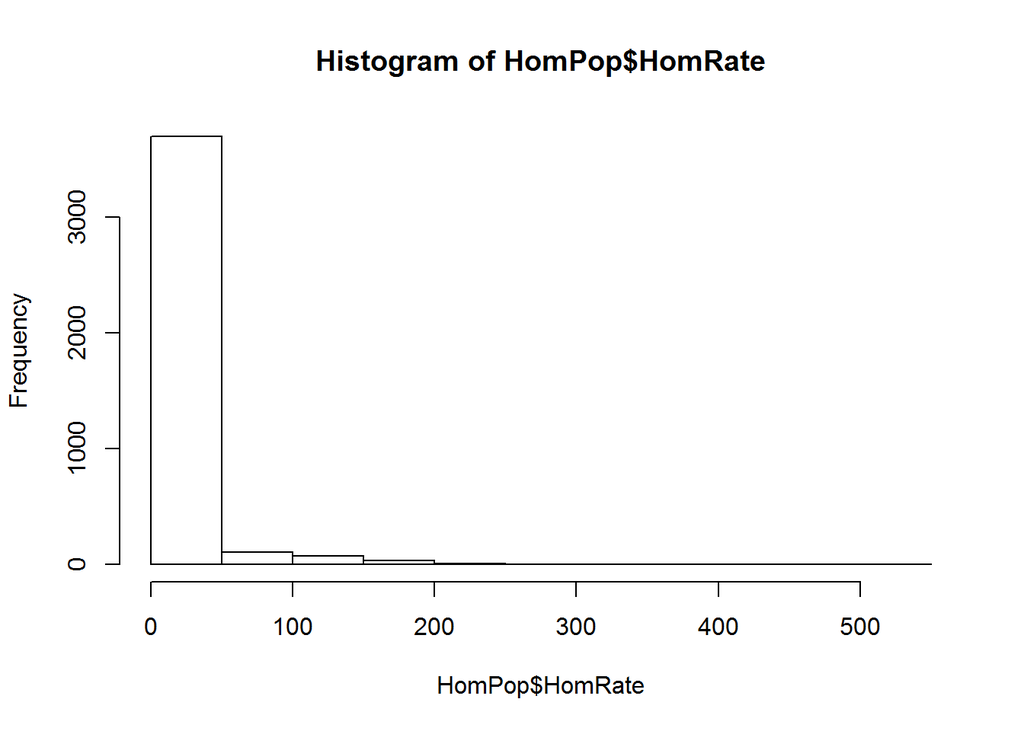

```r
# However, the distribution of Homicide Rates is highly skewed to the right.
hist(HomPop$HomRate)
```

```r
# Since there are no real zeros in the scale of homicide rates, I will log-transform the dependent variable

HomPop$Log_HomRate <- log(HomPop$HomRate)
HomPop$Log_HomRate[which(is.infinite(HomPop$Log_HomRate))] <- NA

ols_log <-lm(Log_HomRate ~ Per15_24, data=HomPop, na.action = na.omit)

summary(ols_log)
```

```
##
## Call:
## lm(formula = Log_HomRate ~ Per15_24, data = HomPop, na.action = na.omit)
##
## Residuals:
##     Min      1Q  Median      3Q     Max
## -4.8868 -0.8442 -0.3228  0.5589  5.1575
##
## Coefficients:
##              Estimate Std. Error t value Pr(>|t|)
## (Intercept) -1.279523   0.116760  -10.96   <2e-16 ***
## Per15_24     0.137459   0.007113   19.33   <2e-16 ***
## ---
## Signif. codes:  0 '***' 0.001 '**' 0.01 '*' 0.05 '.' 0.1 ' ' 1
##
## Residual standard error: 1.391 on 3790 degrees of freedom
##   (2011 observations deleted due to missingness)
## Multiple R-squared:  0.08971,    Adjusted R-squared:  0.08947
## F-statistic: 373.5 on 1 and 3790 DF,  p-value: < 2.2e-16
```

```r
exp(ols_log$coefficients[2])
```

```
## Per15_24
## 1.147354
```

On average, each addition percentage point in the proportion of the population between 15 to 24 years of age, corresponds to 1.1473542. Results are preliminary. They only consider countries and years with observable valid numbers. The model also desconsider the dependence in residuals within countries.

I will later execute a fixed effects model (plm), but only after complementing and cleaning the data.

In particular, many rates are missing due to lack of data on population size, which can be easily acessible from other sources.